# Final Project

Author

Aishwarya Jawalkar

```r
library(fpp3)
library(ggplot2)
library(here)
library(tsibble)
library(knitr)
library(fable)
library(fable.prophet)
library(feasts)
library(slider)
library(fable.prophet)
library(data.table)
```

# Section 1

## Introduction

The provided dataset represents streetcar ridership over time, with two columns: “date” and “ridership.” The data spans from September 2016, to January 2024. The source of the dataset is [Cincinnati Open Data](https://data.cincinnati-oh.gov/Efficient-Service-Delivery/Streetcar-Ridership/wkbu-npen/about_data), and it is published on their platform.

The “ridership” variable indicates the number of streetcar riders on each corresponding date. Potential factors influencing the variation in ridership could include day of the week, weather conditions, special events, public holidays, or other external factors. For example, weekends or holidays might witness higher or lower ridership, and adverse weather conditions could impact the number of people using the streetcar.

Forecasting streetcar ridership may be challenging due to the influence of various external factors. Accurate predictions may require considering additional datasets, such as weather data, event calendars, or public holiday schedules. Additionally, seasonality and trends in ridership patterns over time could contribute to the complexity of forecasting this variable. Implementing advanced time series forecasting models, incorporating external factors, and analyzing historical patterns could enhance the accuracy of predictions for streetcar ridership.

The impact of the COVID-19 pandemic necessitates careful consideration. Therefore, this analysis will incorporate data beyond 2020 or a more nuanced understanding of historical and current trends, ultimately leading to more accurate forecasting models for future streetcar ridership.

```r
filepath <- here("Data","Streetcar_Ridership_20240205.csv")
rd_data <- readr::read_csv(filepath)

rd_tbl <- rd_data %>%
  mutate(date = parse_date_time(date, orders = c("mdy HMSz", "mdy HMsz"))) %>%
  mutate(date = as_date(date))

rd_tsbl <- rd_tbl %>%
  group_by(date) %>%
  summarise(ridership = sum(ridership)) %>%
  mutate(date = yearweek(date)) %>%
  filter(year(date) >= 2021) %>%
  group_by(date) %>%
  summarise(ridership = sum(ridership)) %>%
  as_tsibble(index = date)

rd_tsbl
```

```
# A tsibble: 161 x 2 [1W]
       date ridership
     <week>     <dbl>
 1 2021 W01      4627
 2 2021 W02      5010
 3 2021 W03      4979
 4 2021 W04      4812
 5 2021 W05      5377
 6 2021 W06      4716
 7 2021 W07      4927
 8 2021 W08      6026
 9 2021 W09      7112
10 2021 W10      7096
# ℹ 151 more rows
```

## Summary Statistics

- In this section, we present a comprehensive overview of the summary statistics derived from our Streetcar ridership data, shedding light on its central tendencies, dispersion, and distribution.
- Through measures such as mean, median, standard deviation, and more, we aim to provide a nuanced understanding of the data’s characteristics.

```r
summary(rd_tbl)
```

```
      date              ridership
 Min.   :2016-09-10   Min.   :   0.0
 1st Qu.:2018-07-17   1st Qu.:   5.0
 Median :2020-09-24   Median :  19.0
 Mean   :2020-06-26   Mean   : 276.6
 3rd Qu.:2022-05-26   3rd Qu.: 435.0
 Max.   :2024-01-30   Max.   :6388.0
```

- The ridership data covers a period from 2016-09-10 to 2024-01-30. The data covers almost 7 and a half years.
- This suggests that there might be seasonality in the ridership data. For example, ridership might be higher in the summer months than in the winter months. It would be interesting to explore this further by plotting the ridership data over time.

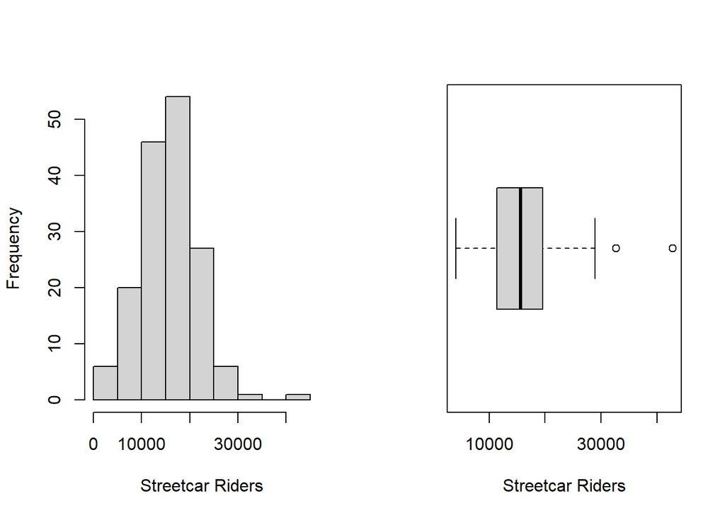

```r
par(mfrow=c(1,2))
hist(rd_tsbl$ridership, xlab="Streetcar Riders", main = "")
boxplot(rd_tsbl$ridership, horizontal = TRUE, xlab = "Streetcar Riders")
```

The fact that the ridership data has a high standard deviation suggests that there is a lot of variability in the ridership, which could be due to seasonality or other factors. The distribution of the timeseries apears to be slightly right skewed. We will find about it in the below sections.

**Density Plot**

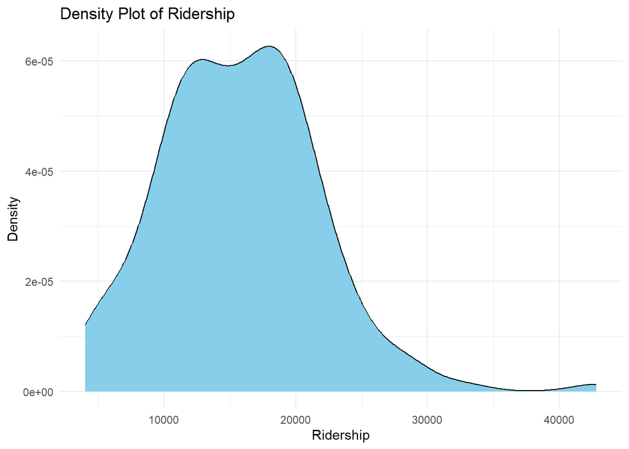

```r
density_plot <- ggplot(rd_tsbl, aes(x = ridership)) +
  geom_density(fill = "skyblue", color = "black") +
  labs(title = "Density Plot of Ridership",
       x = "Ridership",
       y = "Density") +
  theme_minimal()
print(density_plot)
```

## Time series Plot

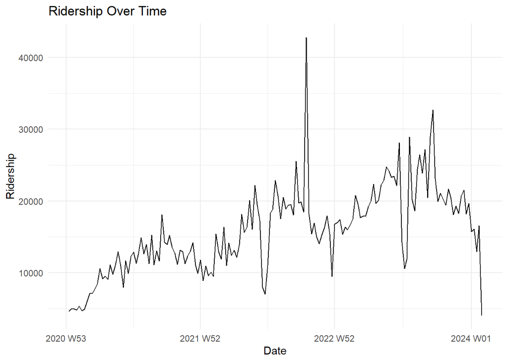

```r
line_chart <- ggplot(rd_tsbl, aes(x = date, y = ridership)) +
  geom_line() +
  labs(title = "Ridership Over Time",
       x = "Date",
       y = "Ridership") +
  theme_minimal()
print(line_chart)
```

## Visualizing Moving Averages

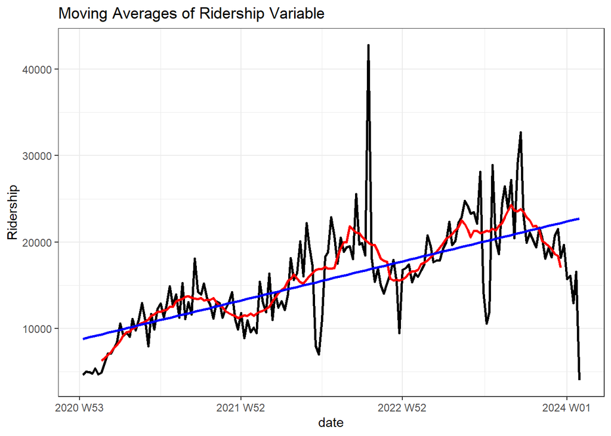

```r
cons_sent_ma <- rd_tsbl %>%
  arrange(date) %>%
  mutate(
    ma_right = slider::slide_dbl(ridership, mean, .before = 12, .after = 0, .complete = TRUE),
    ma_left = slider::slide_dbl(ridership, mean, .before = 0, .after = 12, .complete = TRUE),
    ma_center = slider::slide_dbl(ridership, mean, .before = 6, .after = 6, .complete = TRUE),
    ma_3 = slider::slide_dbl(ridership, mean, .before = 1, .after = 1, .complete = TRUE),
    ma_5 = slider::slide_dbl(ridership, mean, .before = 2, .after = 2, .complete = TRUE),
    ma_7 = slider::slide_dbl(ridership, mean, .before = 3, .after = 3, .complete = TRUE),
    ma_13 = slider::slide_dbl(ridership, mean, .before = 6, .after = 6, .complete = TRUE),
    ma_25 = slider::slide_dbl(ridership, mean, .before = 12, .after = 12, .complete = TRUE),
    ma_49 = slider::slide_dbl(ridership, mean, .before = 24, .after = 24, .complete = TRUE)
  )

cons_sent_ma_pivot <- cons_sent_ma %>%
  pivot_longer(
    cols = ma_right:ma_49,
    values_to = "value_ma",
    names_to = "ma_order"
  ) %>%
  mutate(ma_order = factor(
    ma_order,
    levels = c(
      "ma_center",
      "ma_left",
      "ma_right",
      "ma_3",
      "ma_5",
      "ma_7",
      "ma_13",
      "ma_25",
      "ma_49"
    ),
    labels = c(
      "ma_center",
      "ma_left",
      "ma_right",
      "ma_3",
      "ma_5",
      "ma_7",
      "ma_13",
      "ma_25",
      "ma_49"
    )
  ))

# Visualizing the time series, moving average, and remainder
library(ggplot2)
cons_sent_ma %>%
  ggplot() +
  geom_line(aes(date, ridership), size = 1) +
  geom_line(aes(date, ma_13), size = 1, color = "red") +
  geom_smooth(aes(date, ridership), method = "lm", se = FALSE, color = "blue") +
  theme_bw() +
  ylab('Ridership') +
  ggtitle('Moving Averages of Ridership Variable')
```

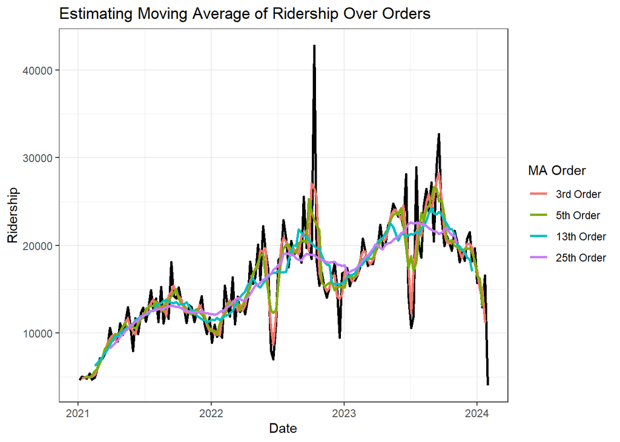

```r
cons_sent_ma_pivot %>%
  filter(
    !ma_order %in% c(
      "ma_center",
      "ma_left",
      "ma_right",
      "ma_7",
      "ma_49"
    )
  ) %>%
  mutate(ma_order = case_when(
    ma_order == 'ma_3' ~ '3rd Order',
    ma_order == 'ma_5' ~ '5th Order',
    ma_order == 'ma_13' ~ '13th Order',
    ma_order == 'ma_25' ~ '25th Order'
  )) %>%
  mutate(
    ma_order = factor(
      ma_order,
      labels = c('3rd Order',
                 '5th Order',
                 '13th Order',
                 '25th Order'),
      levels = c('3rd Order',
                 '5th Order',
                 '13th Order',
                 '25th Order')
    )
  ) %>%
  ggplot() +
  geom_line(aes(as.Date(date), ridership), size = 1) +
  geom_line(aes(as.Date(date), value_ma, color = ma_order), size = 1) +
  scale_color_discrete(name = 'MA Order') +
  theme_bw() +
  labs(
    title = "Estimating Moving Average of Ridership Over Orders",
    x = "Date",
    y = "Ridership"
  )
```

3rd order Moving Average seems to be over fitting. 5th order Moving average seems to be a better fit. So for further analysis we will consider 5th Order Moving Average itself.

**MA Estimate**

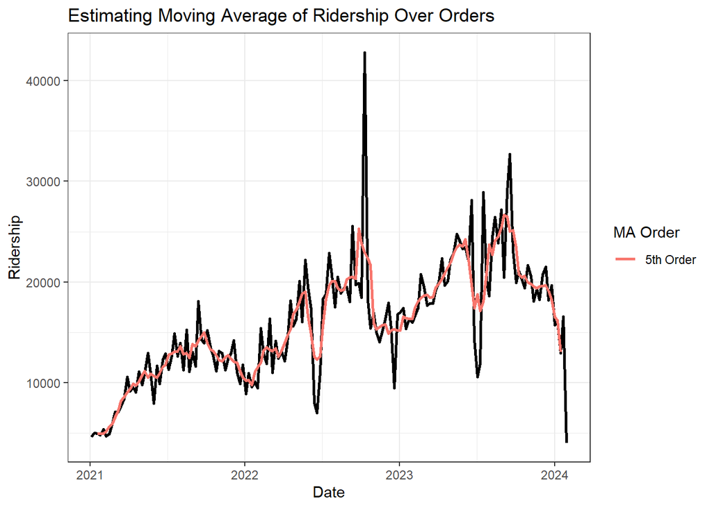

```r
cons_sent_ma_pivot %>%
  filter(
    ma_order == 'ma_5'
  ) %>%
  mutate(ma_order = case_when(
    ma_order == 'ma_5' ~ '5th Order'
  )) %>%
  ggplot() +
  geom_line(aes(as.Date(date), ridership), size = 1) +
  geom_line(aes(as.Date(date), value_ma, color = ma_order), size = 1) +
  scale_color_discrete(name = 'MA Order') +
  theme_bw() +
  labs(
    title = "Estimating Moving Average of Ridership Over Orders",
    x = "Date",
    y = "Ridership"
  )
```

## Decomposition

**Remainder Series of Ridership**

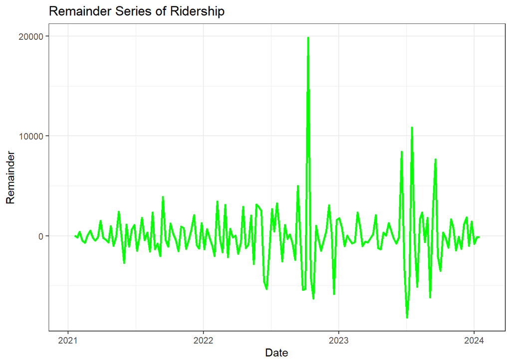

```r
rd_tsbl_ma <- rd_tsbl %>%
  arrange(date) %>%
  mutate(
    ma_5 = slider::slide_dbl(ridership, mean, .before = 2, .after = 2, .complete = TRUE)
  )

# Calculate remainder series
rd_tsbl_ma_remainder <- rd_tsbl_ma %>%
  mutate(remainder = ridership - ma_5)

# Plot the remainder series with fixed y-axis
ggplot(rd_tsbl_ma_remainder, aes(x = as.Date(date), y = remainder)) +
  geom_line(color = "green", size = 1) +
  scale_x_date(date_breaks = "1 year", date_labels = "%Y") +  #
  theme_bw() +
  labs(
    title = "Remainder Series of Ridership",
    x = "Date",
    y = "Remainder"
  )
```

The remainder series suggests that there is more complexity in the ridership data than can be captured by a simple moving average. While the moving average is useful for smoothing out the data and identifying trends, it may mask some of the underlying patterns and relationships in the data.

**Component**

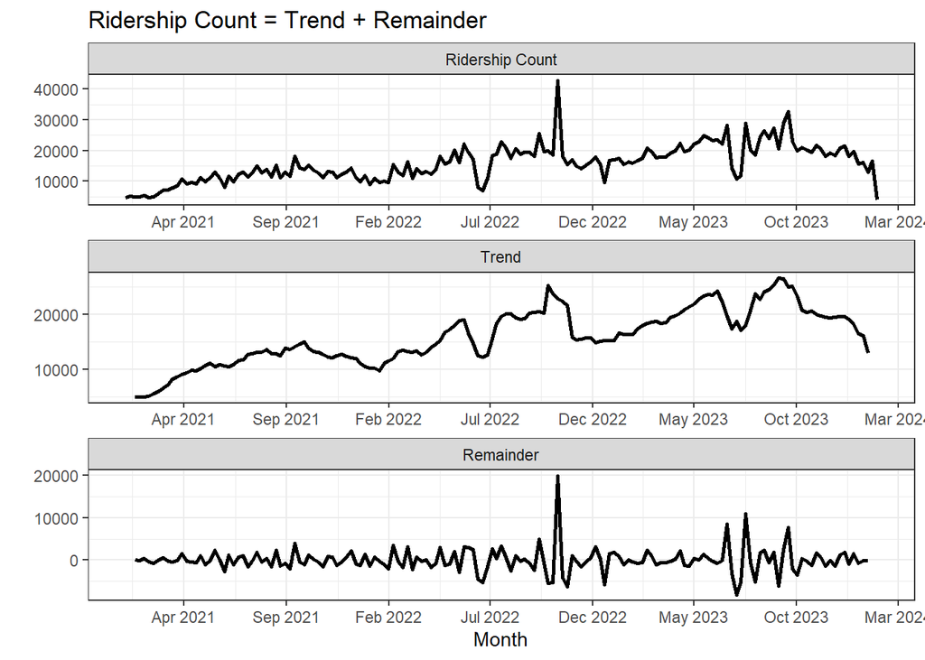

```r
rd_decomp <- rd_tsbl %>%
  mutate(
    ma_center = slider::slide_dbl(ridership, mean,
                .before = 2, .after = 2, .complete = TRUE),
  ) %>%
  mutate(resid = ridership - ma_center) %>%
  dplyr::select(date, ridership, ma_center, resid) %>%
  mutate(date = as.Date(date)) %>% # Convert date column to Date class
  pivot_longer(
    ridership:resid,
    names_to = "decomposition",
    values_to = "ridership"
  ) %>%
  mutate(
    decomposition = case_when(
      decomposition == "ridership" ~ "Ridership Count",
      decomposition == "ma_center" ~ "Trend",
      decomposition == "resid" ~ "Remainder"
    )
  ) %>%
  mutate(
    decomposition = factor(
      decomposition,
      labels = c(
        "Ridership Count",
        "Trend",
        "Remainder"
      ),
      levels = c(
        "Ridership Count",
        "Trend",
        "Remainder"
      )
    )
  )
rd_decomp %>%
  ggplot() +
  geom_line(aes(date, ridership), size = 1) +
  facet_wrap(
    ~decomposition,
    nrow = 3,
    scales = "free"
  ) +
  theme_bw() +
  ylab("") +
  xlab("Month") +
  ggtitle(
    "Ridership Count = Trend + Remainder"
  ) +
  scale_x_date(labels = scales::date_format("%b %Y"), date_breaks = "5 months")
```

There are patterns in the Remainders which suggests that there is some seasonality that is not being captured by other components. We’ll see the Decomposition of the time series to identify the seasonality more clearly.

**Classical Decomposition**

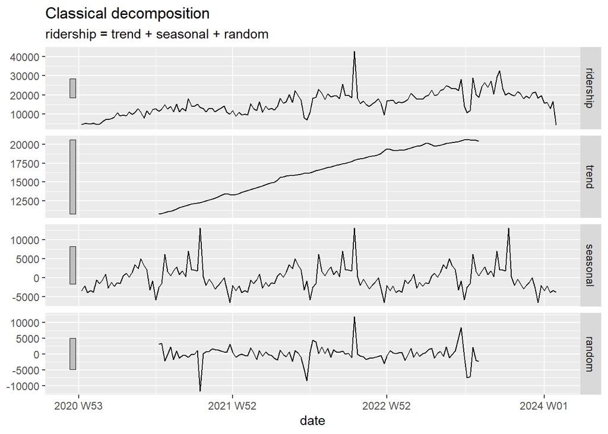

```r
rd_tsbl %>%
  model(
    classical_decomposition(ridership)
  ) %>%
  components() %>%
  autoplot()
```

A clear yearly seasonality is seen here. The remainder seems to be white noise. To see if any correlation is left in the residuals we’ll see the lag plot.

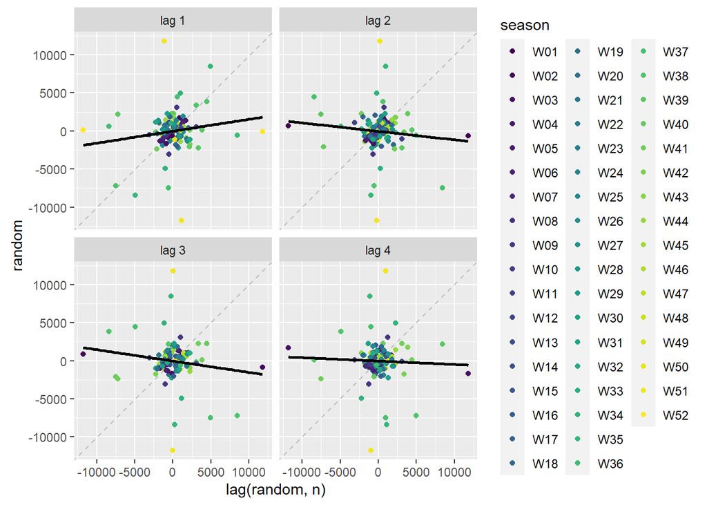

```r
rd_tsbl %>%
  model(
    classical_decomposition(ridership,'additive')
  ) %>%
  components() %>%
  gg_lag(random, geom = "point", lags = 1:4)+
  geom_smooth(aes(color=NULL),method='lm',color='black',se=F)
```

There is no correlation, the time series has additive seasonality.

**Splitting the dataset in train and test**

```r
split_index <- floor(0.8 * nrow(rd_tsbl))

# Select the first 80% of the data
rd_train <- rd_tsbl[1:split_index, ]
rd_test <- rd_tsbl[(split_index + 1):nrow(rd_tsbl),]
```

# Section 2

## Assessment of whether data are variance/mean stationary.

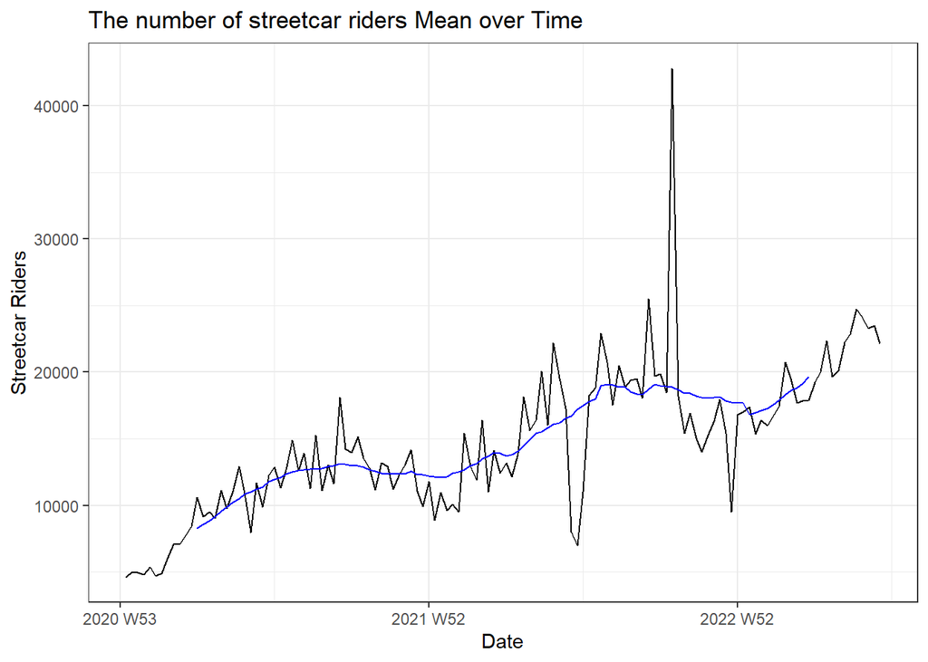

```r
#Rolling average method to check whether the timeseries is mean stationary.

rd_roll <- rd_train %>%
  mutate(
    ridership_mean = slide_dbl(
      ridership,
      mean,
      .before=12,
      .after=12,
      .complete=TRUE),
    ridership_sd = slide_dbl(
      ridership,
      sd,
      .before=12,
      .after=12)
  )

rd_rollmean <- rd_roll %>%
  ggplot() +
    geom_line(aes(date, ridership)) +
  geom_line(aes(date, ridership_mean),color='blue') +
  theme_bw() +
  ggtitle("The number of streetcar riders Mean over Time") +
  ylab("Streetcar Riders") +
  xlab("Date")

rd_rollmean
```

From this graph it is visible that the timeseries is not mean stationary.

**Rolling SD method to check whether the timeseries is variance stationary.**

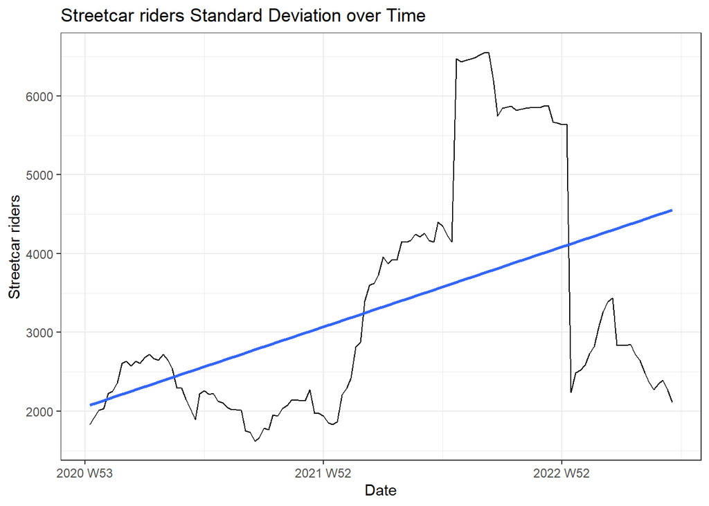

```r
rd_rollsd <- rd_roll %>%
  ggplot() +
  geom_line(aes(date, ridership_sd)) +
  geom_smooth(aes(date,ridership_sd),method='lm',se=F)+
  theme_bw() +
  ggtitle("Streetcar riders Standard Deviation over Time") +
  ylab("Streetcar riders") +
  xlab("Date")

rd_rollsd
```

This graph is clearly showing upward trend and telling that the timeseries is not variance stationary. To induce variance stationarity in the timeseries there are two approaches.

## Transformation of Data

To make a series variance stationary we will perform 2 types of transformations:

1. Log Transformation
2. Box-Cox Transformation

**Log Transformation**

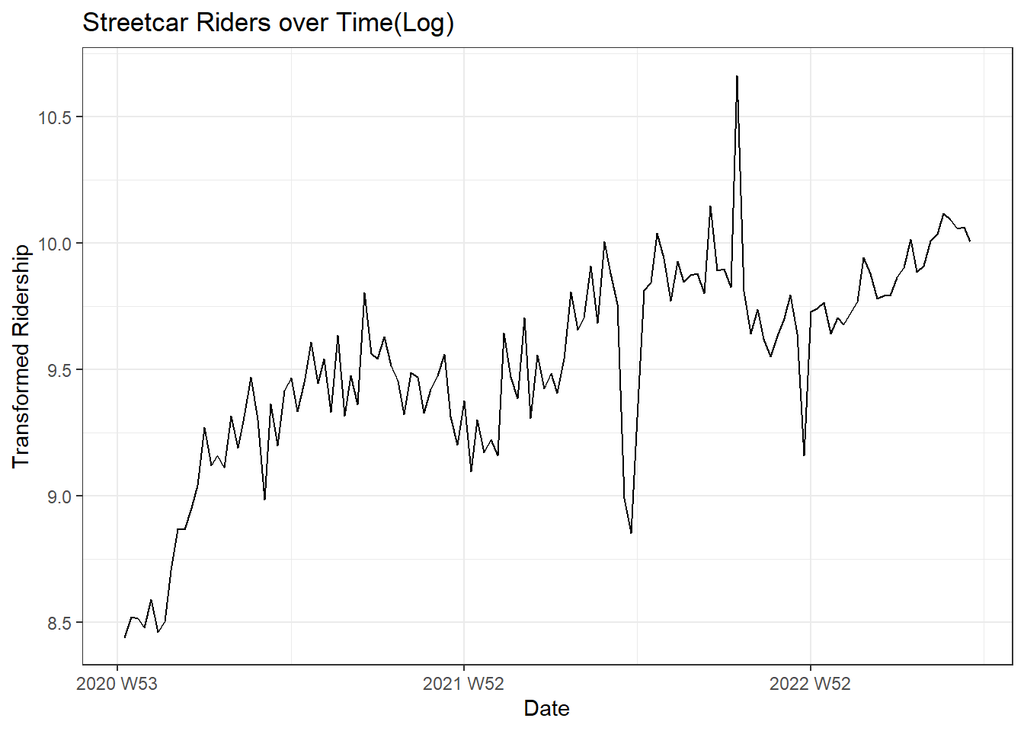

```r
library(ggtext)
lambda = rd_train %>%
  as_tsibble() %>%
  features(ridership, features = guerrero) %>%
  pull(lambda_guerrero)

rd_trans <- rd_train %>%
  mutate(ridership_log = log1p(ridership)) %>%
  mutate(ridership_boxcox = box_cox(ridership,lambda))

rd_trans %>%
  ggplot() +
  geom_line(aes(date, ridership_log)) +
  theme_bw() +
  labs(title = "Streetcar Riders over Time(Log)",
       x = "Date",
       y = "Transformed Ridership") +
  theme(plot.title = ggtext::element_markdown())
```

**Box-Cox Transformation**

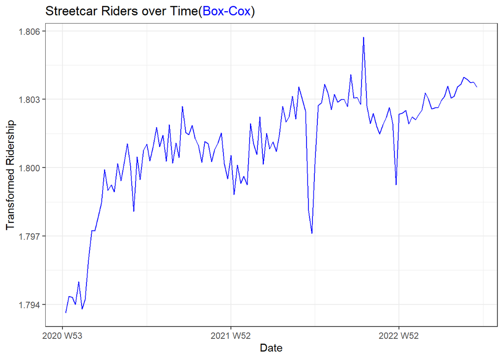

```r
rd_trans %>%
  ggplot() +
  geom_line(aes(date, ridership_boxcox),color='blue') +
  theme_bw() +
  labs(title = "Streetcar Riders over Time(<span style='color:blue'>Box-Cox</span>)",
       x = "Date",
       y = "Transformed Ridership") +
  theme(plot.title = ggtext::element_markdown())
```

**Rolling SD of Log transformed timeseries**

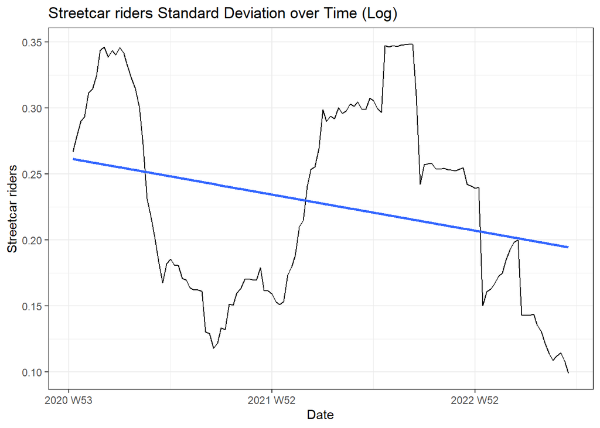

```r
rd_log_roll <- rd_trans %>%
  mutate(log_ridership_sd = slide_dbl(
      ridership_log,
      sd,
      .before=12,
      .after=12)
  )

rd_log_rollsd <- rd_log_roll %>%
  ggplot() +
  geom_line(aes(date, log_ridership_sd)) +
  geom_smooth(aes(date,log_ridership_sd),method='lm',se=F)+
  theme_bw() +
  ggtitle("Streetcar riders Standard Deviation over Time (Log)") +
  ylab("Streetcar riders") +
  xlab("Date")

rd_log_rollsd
```

**Rolling SD of Box-Cox transformed timeseries**

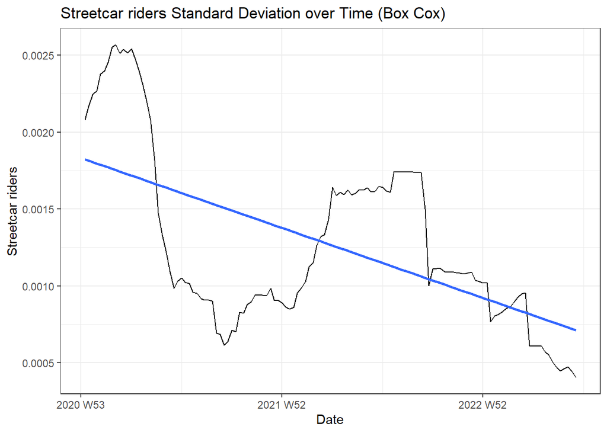

```r
rd_box_cox_roll <- rd_trans %>%
  mutate(box_cox_ridership_sd = slide_dbl(
      ridership_boxcox,
      sd,
      .before=12,
      .after=12)
  )

rd_box_rollsd <- rd_box_cox_roll %>%
  ggplot() +
  geom_line(aes(date, box_cox_ridership_sd)) +
  geom_smooth(aes(date,box_cox_ridership_sd),method='lm',se=F)+
  theme_bw() +
  ggtitle("Streetcar riders Standard Deviation over Time (Box Cox)") +
  ylab("Streetcar riders") +
  xlab("Date")

rd_box_rollsd
```

We will check for seasonality in the data.

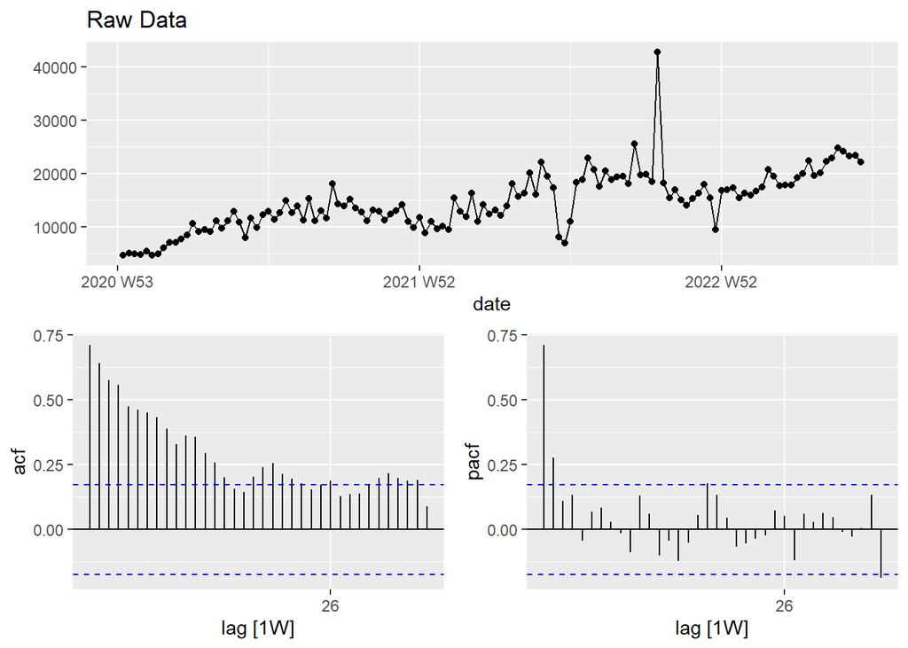

```r
rd_train %>%
  gg_tsdisplay(ridership,plot_type='partial', lag=36) +
  labs(title="Raw Data", y="")
```

The data has seasonality so we will do seasonal differencing.

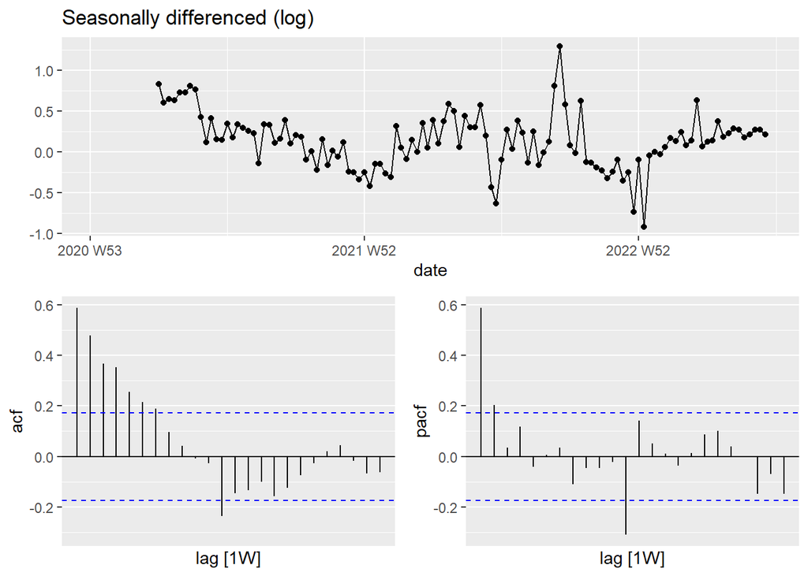

```r
rd_train %>%
  gg_tsdisplay(difference(log(ridership),12),
               plot_type='partial', lag=24) +
  labs(title="Seasonally differenced (log)", y="")
```

Further, to see if there is mean stationarity, we will first see difference of log values.

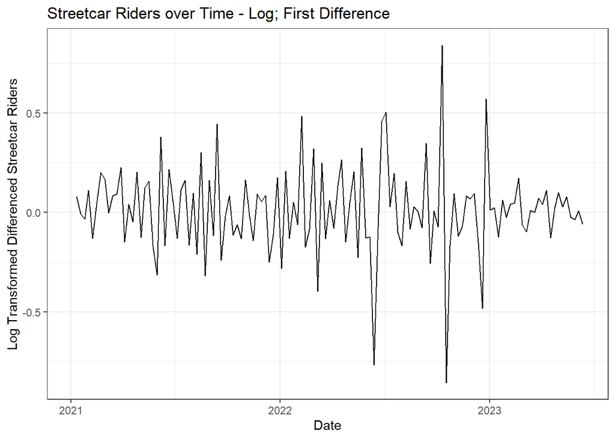

```r
rd_diff <- rd_trans %>%
  mutate(ridership_diff = ridership_log - lag(ridership_log)) %>%
  as_tsibble(index=date)

rd_diff <- rd_diff %>%
  mutate(date = as.Date(date))

rd_diff %>%
  ggplot() +
  geom_line(aes(date, ridership_diff)) +
  theme_bw() +
  ggtitle("Streetcar Riders over Time - Log; First Difference") +
  ylab("Log Transformed Differenced Streetcar Riders") +
  xlab("Date") +
  scale_x_date(date_breaks = "1 years", date_labels = "%Y") +
  theme_bw()
```

Looking at the graph, we can see that the timeseries is almost mean stationary.

So, now we’ll conduct KPSS test for stationarity.

```r
#KPSS test for raw data
raw_value_kpss <- rd_tsbl %>%
features(ridership, unitroot_kpss)
raw_value_kpss
```

```
# A tibble: 1 × 2
  kpss_stat kpss_pvalue
      <dbl>       <dbl>
1      2.20        0.01
```

**KPSS test for Log transformed data**

```r
#KPSS test for Log transformed data
log_trans_value_kpss <- rd_trans %>%
features(ridership_log, unitroot_kpss)
log_trans_value_kpss
```

```
# A tibble: 1 × 2
  kpss_stat kpss_pvalue
      <dbl>       <dbl>
1      1.87        0.01
```

**KPSS test for Box Cox transformed data**

```r
#KPSS test for Box Cox transformed data
box_cox_trans_value_kpss <- rd_trans %>%
features(ridership_boxcox, unitroot_kpss)
box_cox_trans_value_kpss
```

```
# A tibble: 1 × 2
  kpss_stat kpss_pvalue
      <dbl>       <dbl>
1      1.72        0.01
```

**KPSS test for differenced log transformed data**

```r
#KPSS test for differenced log transformed data
log_diff_value_kpss <- rd_diff %>%
features(ridership_diff, unitroot_kpss)
log_diff_value_kpss
```

```
# A tibble: 1 × 2
  kpss_stat kpss_pvalue
      <dbl>       <dbl>
1    0.0745         0.1
```

The KPSS test for differenced log transformed data suggests that the data is mean stationary and its also visible from the graph above.

## Examination of ACF/PACF

**ACF and PACF plots.**

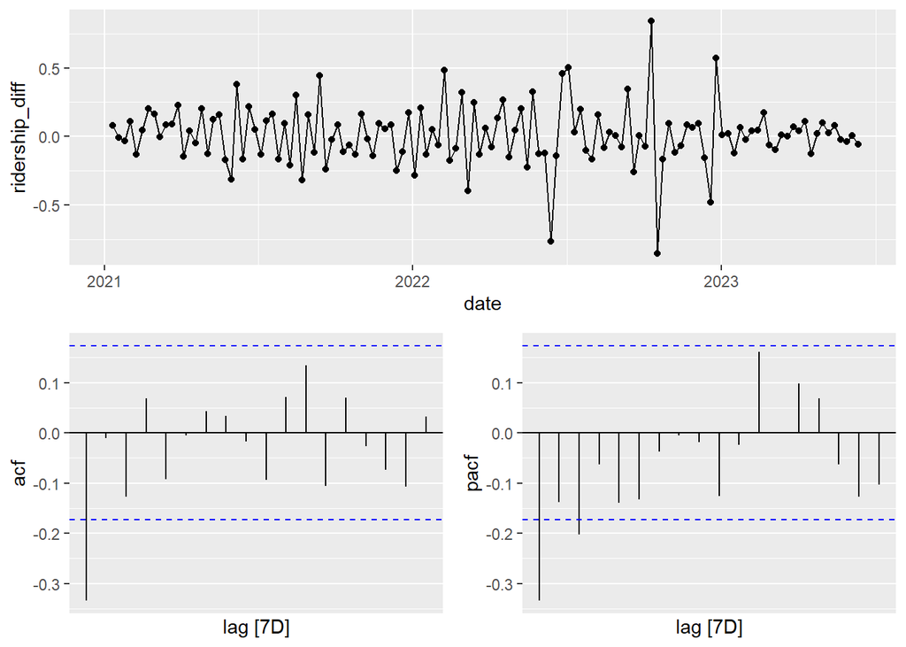

```r
rd_diff %>%
  gg_tsdisplay(ridership_diff, plot_type = 'partial', lag_max = 18 )
```

After analyzing the ACF and PACF plots, it appears that the time series follows a moving average (MA) mmodel and auto regressive (AR) model. The ACF plot shows no damping effect, indicating a possible MA model. Furthermore, the PACF plot exhibits significant lag values at lag 1, suggesting an MA model of order 1.

Based on these findings, the time series can be represented by an ARIMA(1,1,1) model, indicating a bit autoregressive (AR) component, first-order differencing (d=1), and a moving average component of order 1 (q=1). Since there’s is evidence of seasonality in the data, the seasonal component (P, D, Q) is assumed to be (0,1,0).

## ARIMA Model selection.

Let’s build some models and compare them based on the BIC values.

```r
models_bic <- rd_trans %>%
  model(
    mod1 = ARIMA(log(ridership)~pdq(1,1,3)+PDQ(0,1,0)),
    mod2 = ARIMA(log(ridership)~pdq(0,1,3)+PDQ(1,0,0)),
    mod3 = ARIMA(log(ridership)~pdq(1,1,1)+PDQ(0,1,0)),
    mod4 = ARIMA(log(ridership)~pdq(1,1,2)+PDQ(0,1,0)),
    mod5 = ARIMA(log(ridership)~pdq(2,1,2)+PDQ(0,1,0))

  )

models_bic %>%
  glance() %>%
  arrange(BIC)
```

```
# A tibble: 4 × 8
  .model sigma2 log_lik   AIC  AICc   BIC ar_roots  ma_roots
  <chr>   <dbl>   <dbl> <dbl> <dbl> <dbl> <list>    <list>
1 mod3   0.0708   -6.74  19.5  19.8  26.4 <cpl [1]> <cpl [1]>
2 mod4   0.0718   -6.74  21.5  22.1  30.7 <cpl [1]> <cpl [2]>
3 mod5   0.0704   -5.76  21.5  22.4  33.1 <cpl [2]> <cpl [2]>
4 mod1   0.0724   -6.53  23.1  23.9  34.7 <cpl [1]> <cpl [3]>
```

Based on the BIC values above, model 3 ARIMA(1,1,1)(0,1,0) seems to be the best one.  
It’s close to what we have predicted above based on the ACF and PACF plots.

Let’s check what **Auto ARIMA** gives us.

```r
best_model <- rd_train %>%
  model(
    ARIMA(log(ridership),approximation=F,stepwise = F) ) %>%
  report()
```

```
Series: ridership
Model: ARIMA(1,1,1)(0,1,0)[52]
Transformation: log(ridership)

Coefficients:
         ar1      ma1
      0.3486  -0.9262
s.e.  0.1388   0.0671

sigma^2 estimated as 0.07082:  log likelihood=-6.74
AIC=19.49   AICc=19.83   BIC=26.44
```

Its giving us ARIMA(1,1,1)(0,1,0) - what we predicted as it has AR(1), I(1), MA(1) and PDQ of (0,1,0)  
It tells us that the time series is dependent on the previous lag as well. In summary, the ARIMA(1,1,1)(0,1,0) model suggests that the time series is dependent on both its own lagged values and the errors of the one preceding observation and the seasonal difference.

**Fitted values plotted against the observed values of the series**

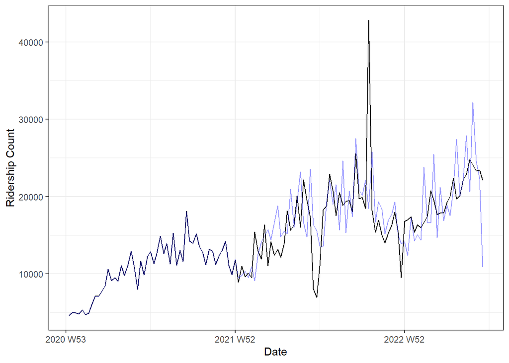

```r
fitted <- best_model %>%
  augment() %>%
  .$.fitted

ggplot() +
  geom_line(aes(rd_train$date, rd_train$ridership)) +
  geom_line(aes(rd_train$date, fitted), color = "blue", alpha = 0.4) +
  theme_bw() +
  xlab("Date") +
  ylab("Ridership Count")
```

## Analysis of Residuals

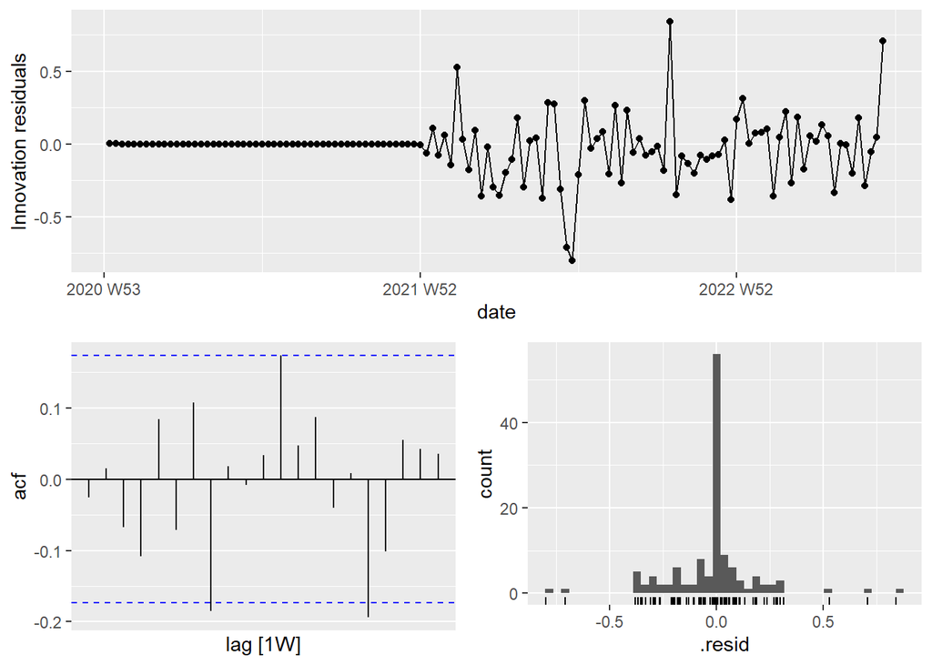

```r
best_model %>%
  gg_tsresiduals()
```

**Box-Ljung Test**

```r
best_model %>%
  augment() %>%
  features(.innov,ljung_box,lag = 10, dof = 4)
```

```
# A tibble: 1 × 3
  .model                                                 lb_stat lb_pvalue
  <chr>                                                    <dbl>     <dbl>
1 ARIMA(log(ridership), approximation = F, stepwise = F)    10.4     0.110
```

The p value here is > 0.05. It indicates that there is no autocorrelation between residuals of the best model. The residuals appear to be white noise.

# Section 3

## Fitting Prophet Model

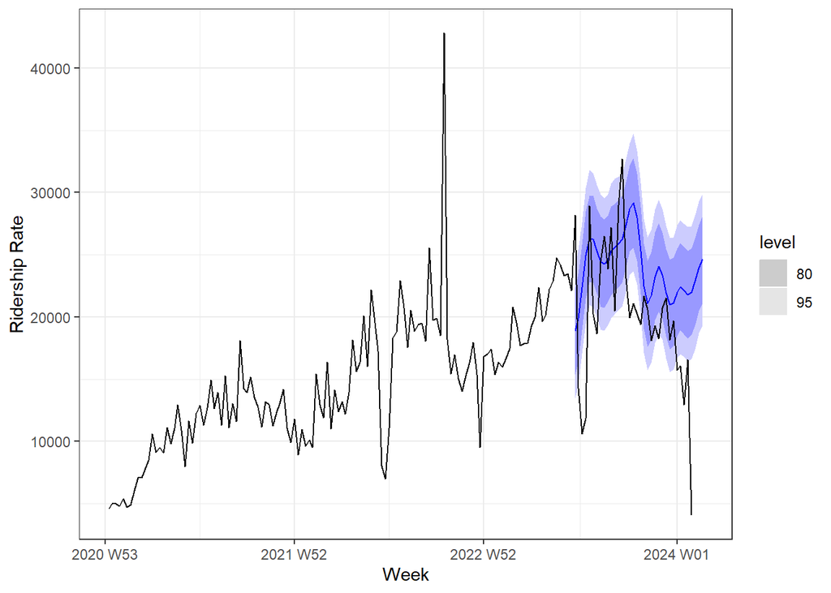

```r
rd_train %>%
    model(prophet = prophet(ridership)) %>%
    forecast(h=36)%>%
    autoplot(rd_train %>% bind_rows(rd_test))+
    ylab('Ridership Rate') +
    xlab('Week') +
    theme_bw()
```

## Decomposition of Elements

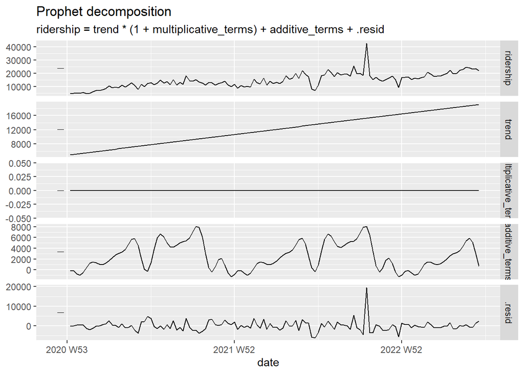

```r
model = rd_train %>%
    model(prophet = fable.prophet::prophet(ridership))

model %>%
components() %>%
autoplot()
```

## Assessment of Changepoints

**Changepoints identified**

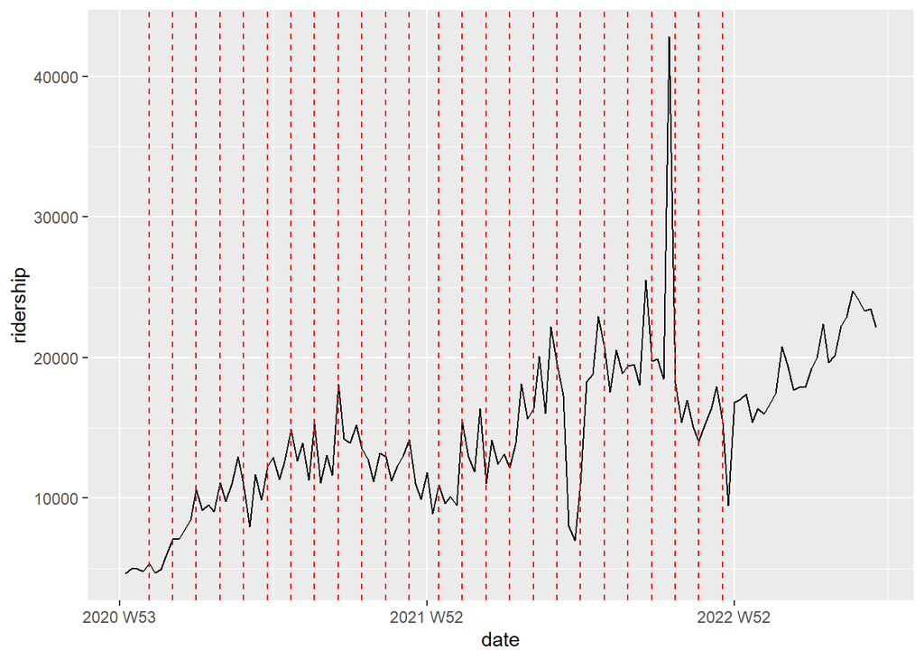

```r
changepoints = model %>%
glance() %>%
pull(changepoints) %>%
bind_rows() %>%
.$changepoints

rd_train %>%
ggplot()+
geom_line(aes(date,ridership))+
# geom_vline(aes(xintercept=ymd('2000-01-01')))
geom_vline(xintercept=as.Date(changepoints),color='red',linetype='dashed')
```

The above graph shows the changepoints identified by Facebook Prophet in streetcar ridership data. These changepoints divide the time series into segments with distinct trends, potentially reflecting seasonal patterns or external events.

These are some observations that were derived from the graph.

- **Seasonality:** The changepoints roughly align with potential seasonal variations, with potential drops around winter and peaks in summer. However, further analysis is needed to confirm this.
- **Upward trend:** There’s a general upward trend in ridership across the entire period, but there are also fluctuations and some segments with different slopes.
- **Changepoint distribution:** The changepoints are somewhat evenly distributed throughout the time series, suggesting Prophet might have captured potential shifts in trends.

No major changes detected, so no need to change the hyper parameters.

## Detection of Saturation Point.

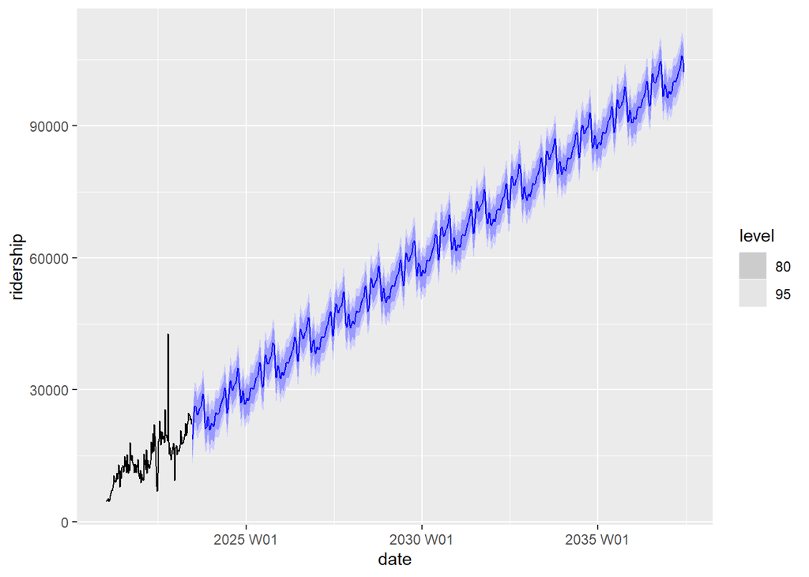

```r
rd_train %>%
    model(
        prophet_orig = fable.prophet::prophet(ridership)
        ) %>%
    forecast(h=730) %>%
    autoplot(rd_train)
```

**Specifying Saturation Point**

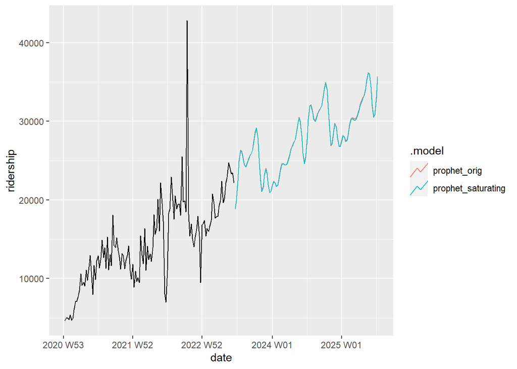

```r
rd_train %>%
    model(
        prophet_orig = fable.prophet::prophet(ridership),
        prophet_saturating = fable.prophet::prophet(ridership~growth(type='linear')+season('year'))
        ) %>%
    forecast(h=108) %>%
    autoplot(rd_train %>%
    filter(year(date) >= 2021),level=NULL)
```

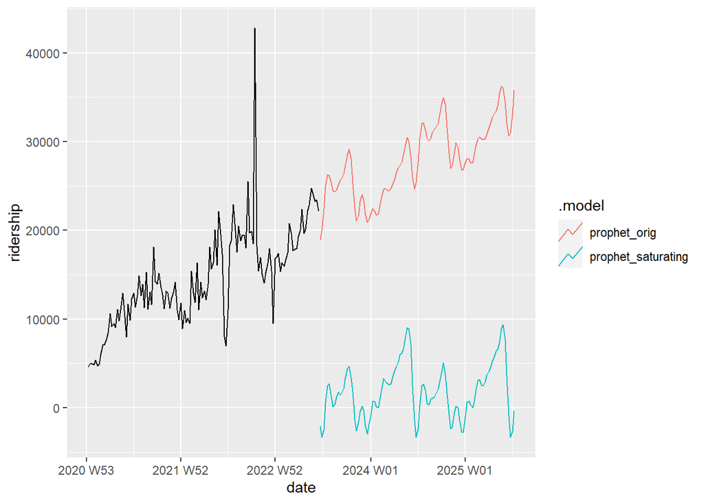

```r
rd_train %>%
    model(
        prophet_orig = fable.prophet::prophet(ridership),
        prophet_saturating = fable.prophet::prophet(ridership~growth(type='logistic',capacity=2000,floor=0)+season('year'))
        ) %>%
    forecast(h=108) %>%
    autoplot(rd_train %>%
    filter(year(date) >= 2021),level=NULL)
```

The analysis of the time-series data revealed a clear linear trend rather than a logistic trend. This observation is supported by the graphical representation of the data, which demonstrates a consistent linear increase or decrease over time, without any evident saturation or leveling-off characteristic of a logistic trend.

## Seasonality

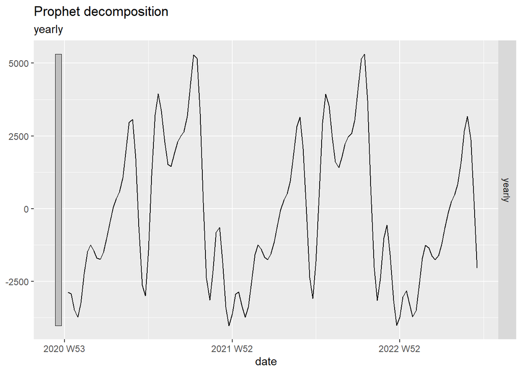

```r
yearly_seasonality = model %>%
components() %>%
autoplot(yearly)

yearly_seasonality
```

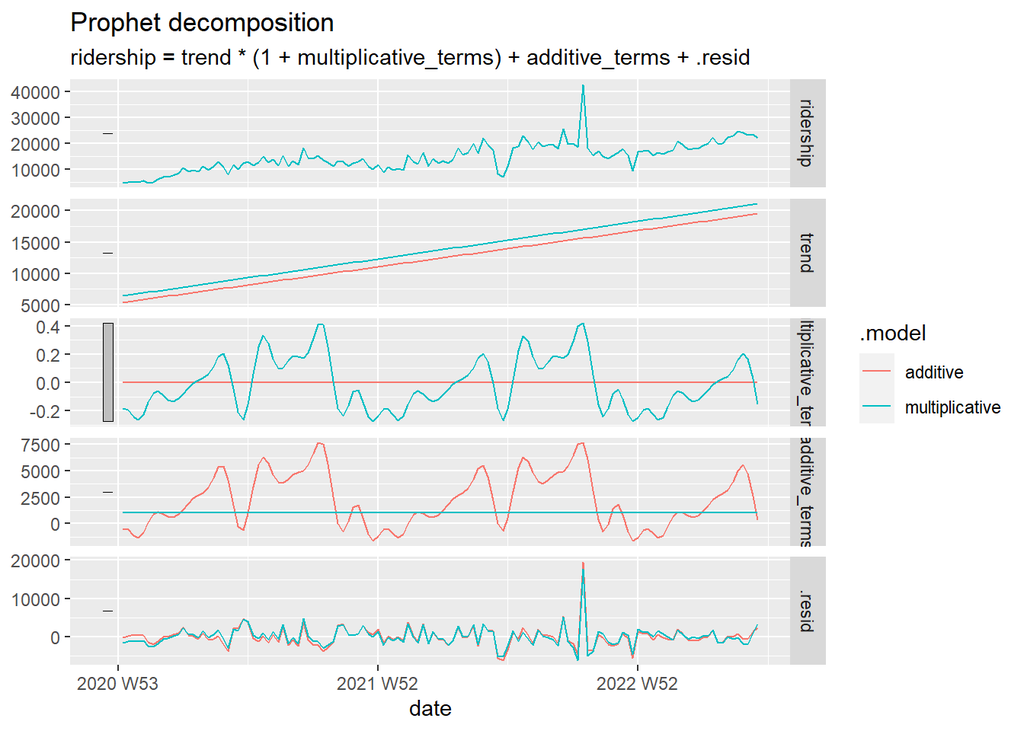

```r
model5 = rd_train %>%
    model(
      additive = fable.prophet::prophet(ridership~growth()+season(period='year',type='additive')+season(period='week')),
      multiplicative = fable.prophet::prophet(ridership~growth()+season(period='year',type='multiplicative')+season(period='week')))

model5 %>%
components() %>%
autoplot()
```

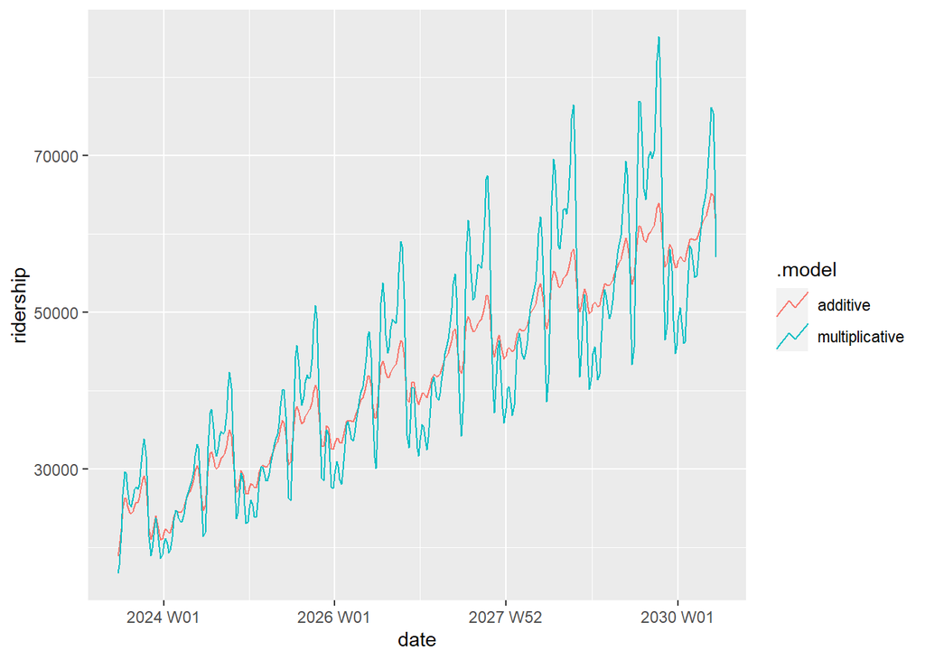

```r
model5 %>%
forecast(h=365) %>%
autoplot(level=NULL)
```

The analysis of the time-series data has revealed a significant yearly seasonality pattern, characterized by a dip in activity during the winter months and an increase during the summer months. This seasonality is identified as additive, indicating that the seasonal fluctuations occur independently of the overall trend of the data. Given the yearly nature of the seasonality and its clear pattern without significant deviations, incorporating holidays into the model is deemed unnecessary. Therefore, the model is specified without including holiday effects.